# Determining Differences Between Forms of Writing Using Sentiment Analysis

In the realm of writing, one often distinguishes between fiction versus nonfiction. In many instances, one can determine if a document is fiction or nonfiction simply by its contents. If this is the case for humans, it would be of interest to see if it could be achieved automatically. Utilizing machine learning to perform such a task is beyond the scope of this course, but potential leads for how to determine a difference will be explored.

The chosen direction of exploration utilized sentiment analysis, or the computational determination of the emotional content of text. One could hypothesize, considering that fiction and nonfiction are intended for distinct functions, that the style of writing could be a prominent indicator, of which sentiment is a component. The sentiment analysis performed here was done using the Tidytext library by Silge and Robinson.

One form of sentiment analysis is to give segments of a text a score based on how many words contained within have a particular sentiment. Because many fictional works have a narrative structure, perhaps the sentiment scores will respect that structure. This would make identifiable structure within the sentiment over time a distinguishing feature of fiction. Does this idea hold up? To determine this, various texts were downloaded from Project Gutenberg using the gutenbergr library.

Some works, such as Dante Alighieri’s *Divine Comedy*, have a very obvious pattern, as can be seen in the graph generated by the following code.

```r
library(tidyr)
library(dplyr)
library(magrittr)
```

```
## Determining mirror for Project Gutenberg from http://www.gutenberg.org/robot/harvest
```

```
## Using mirror http://aleph.gutenberg.org
```

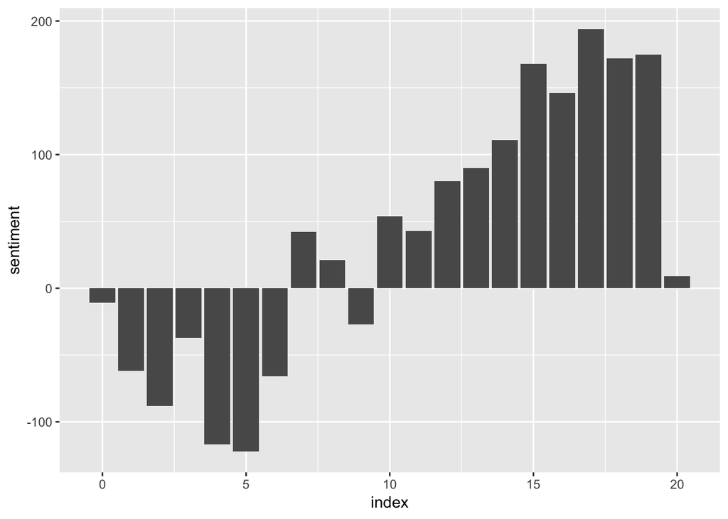

```r
library(stringr)
library(ggplot2)
library(tidytext)
library(gutenbergr)

book_sentiment <- function(id, seg_length) {
  #id is the gutenberg_id of the desired document
  #seg_length is the number of lines that are analyzed at a time
  #This only works with text documents
  #This returns a tibble which associates each segment of the book with
  #a score based on the sentiment values of the words in the segment
  #This uses the Bing lexicon for scoring
  return(
    gutenberg_download(id) %>%
      mutate(linenumber = row_number()) %>%
      unnest_tokens(word, text) %>%
      inner_join(get_sentiments("bing")) %>%
      count(index = linenumber %/% seg_length, sentiment) %>%
      spread(sentiment, n, fill = 0) %>%
      mutate(sentiment = positive - negative)
    )
}

book_sentiment_graph <- function(id, seg_length) {
  #This creates a visual of the book_sentiment function
  book_sentiment(id, seg_length) %>%
    ggplot(aes(index, sentiment)) +
    geom_col()
}

book_sentiment_graph(1004, 1000)
```

This work shows a clear increase from very negative sentiment to very positive sentiment over the course of the narrative. Considering the content of the work, that being a journey through the afterlife whose ultimate conclusion is the protagonist meeting God, this comes as no surprise.

The problem with this type of analysis is revealed, however, when one begins to examine other works. For instance, Lewis Carroll’s *Through the Looking-Glass* exhibits a much different structure.

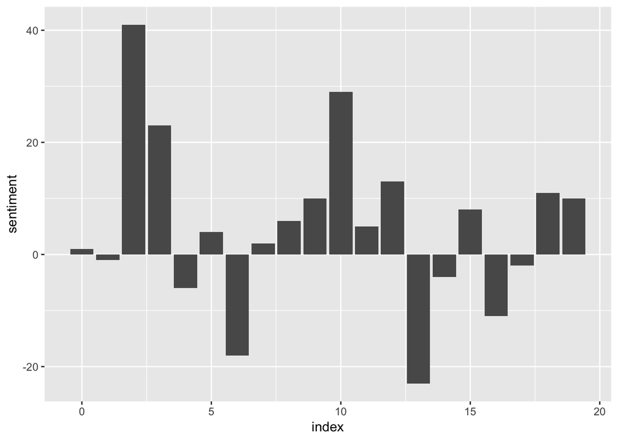

```r
book_sentiment_graph(12, 200)
```

The most noticeable feature of this text when compared to the *Divine Comedy* is that it does not follow a linear trend of some sort. Instead, it appears vaguely oscillatory. As it turns out, the issue with analyzing *Through the Looking-Glass* is that the way our score was done was by taking a count of positive sentiment words and subtracting a count of negative sentiment words. If we instead score based on counts of all emotionally-charged words, regardless of sentiment, then a much different picture emerges.

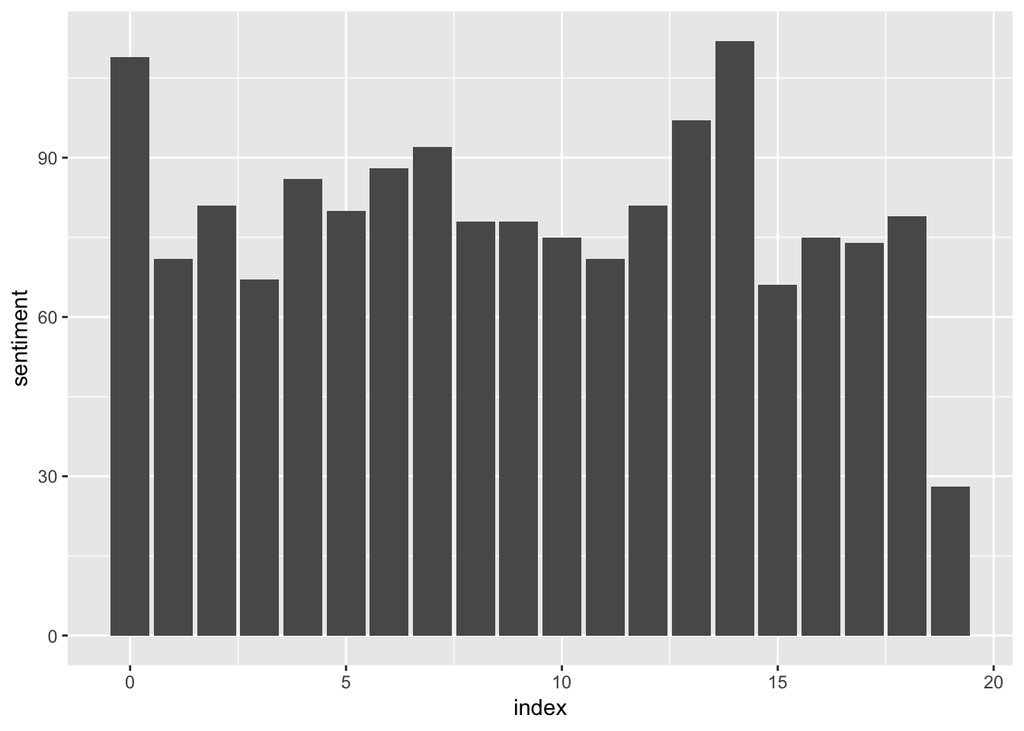

```r
book_sentiment_absolute <- function(id, seg_length) {
  return(
    gutenberg_download(id) %>%
      mutate(linenumber = row_number()) %>%
      unnest_tokens(word, text) %>%
      inner_join(get_sentiments("bing")) %>%
      count(index = linenumber %/% seg_length, sentiment) %>%
      spread(sentiment, n, fill = 0) %>%
      mutate(sentiment = positive + negative)
    )
}

book_sentiment_absolute_graph <- function(id, seg_length) {
  book_sentiment_absolute(id, seg_length) %>%
    ggplot(aes(index, sentiment)) +
    geom_col()
}

book_sentiment_absolute_graph(12, 200)
```

This shows much more consistent levels of sentiment throughout the work. The main reason for the vast differences between the two analyses is that the Literary Nonsense that permeates much of the text throws off the standard scoring mechanism.

For completion’s sake, the following is the *Divine Comedy*’s absolute sentiment scores. It appears visually similar to *Through the Looking-Glass* in this regard.

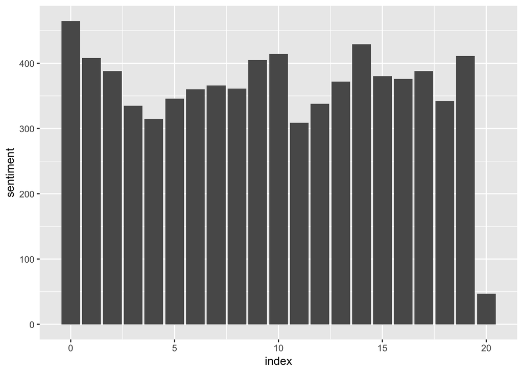

```r
book_sentiment_absolute_graph(1004, 1000)
```

All of the examples explored so far have been fictional works. If a nonfiction work was analyzed, how different would it be?

As an example, here is Albert Einstein’s *Sidelights on Relativity* put through the same two analyses.

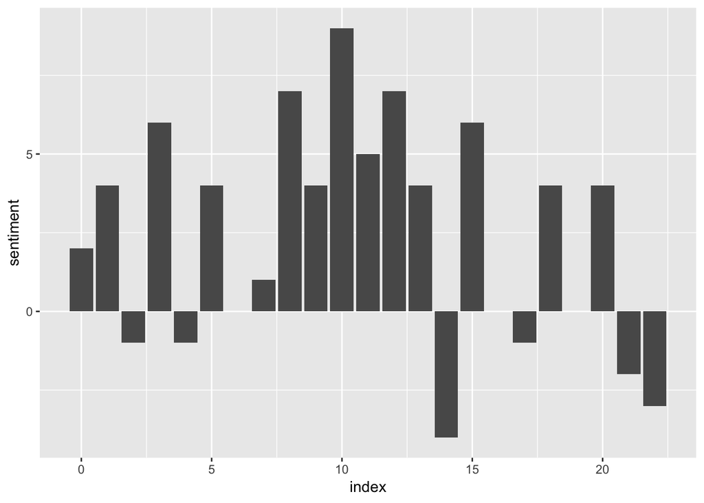

```r
book_sentiment_graph(7333, 40)
```

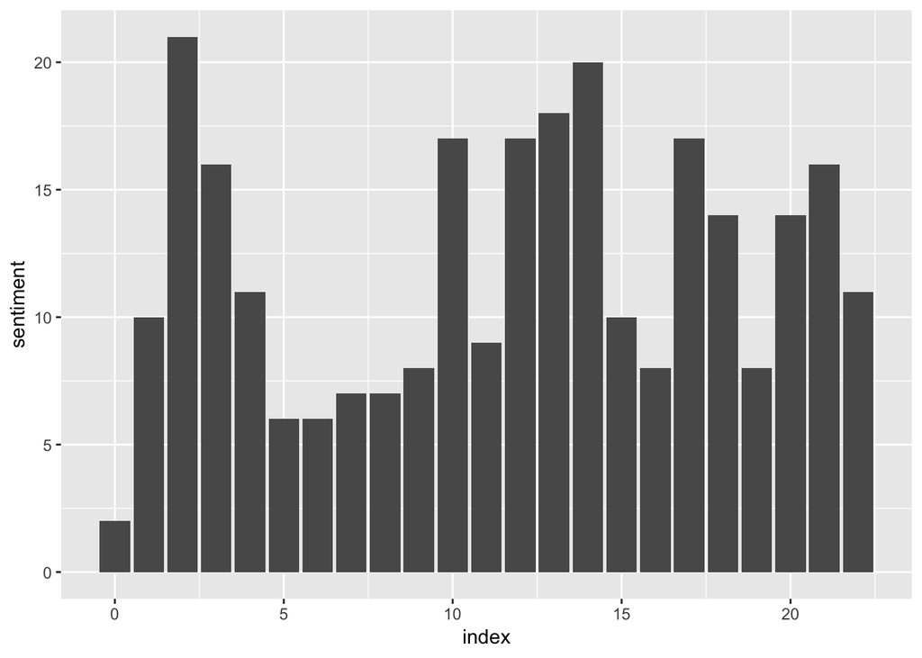

```r
book_sentiment_absolute_graph(7333, 40)
```

As one can see, the shape of the sentiment graphs, particularly the absolute graph, are unlike any of the fictional texts analyzed. There are two obvious explanations of this phenomenon: 1) the primary purpose of this text is to convey information, not to convey an experience, and 2) the text contains far more words that are considered neutral due to being scientific terms unfamiliar to most of the general public.

By now, one feature about the graphs of the sentiment scores that has not been discussed is the fact that, even with the texts whose absolute sentiment graphs looked vaguely similar, their upper and lower bounds were noticeably different. The reason for this is that the graphs were made to have similar numbers of segments, regardless of the actual length of the document. This leads to more text being in the segments for some documents when compared to others. However, despite the differences in the raw value, the similarity of the shapes of the graphs shows that the values attained are roughly proportional to the amount of text in a particular segment.

Due to both the problem of potentially cancelling sentiments and the fact that the scores are roughly proportional to the amount of text in a segment, perhaps a better measure of sentiment is the proportion of sentiment-charged terms within a document. The code used to calculate this proportion is displayed below.

To see if this proportion is a reasonable way to approximate fictionality, it shall be applied to multiple works, these being three fictional works followed by three nonfiction works, with an emphasis on varying types of works for each category.

```r
book_sentiment_ratio <- function(id) {
  temp_book <- gutenberg_download(id) %>%
    unnest_tokens(word, text) %>%
    left_join(get_sentiments("bing")) %>%
    count(sentiment)
  return(
    sum((filter(temp_book, (sentiment == "positive")|(sentiment == "negative")))[, 2])
    / sum(temp_book[, 2])
  )
}

print(str_glue("The Divine Comedy: ", as.character(book_sentiment_ratio(1004))))
```

```
## The Divine Comedy: 0.0655207402846315
```

```r
print(str_glue("Through the Looking-Glass: ", as.character(book_sentiment_ratio(12))))
```

```
## Through the Looking-Glass: 0.0534770163327159
```

```r
print(str_glue("The Prose Edda: ", as.character(book_sentiment_ratio(11))))
```

```
## The Prose Edda: 0.0531954746384955
```

```r
print(str_glue("Sidelights on Relativity: ", as.character(book_sentiment_ratio(7333))))
```

```
## Sidelights on Relativity: 0.0315206096293731
```

```r
print(str_glue("The Voyage of the Beagle: ", as.character(book_sentiment_ratio(944))))
```

```
## The Voyage of the Beagle: 0.051128173588822
```

```r
print(str_glue("The Declaration of Independence: ", as.character(book_sentiment_ratio(1))))
```

```
## The Declaration of Independence: 0.0577999513263568
```

Upon examining the ratios, the two works that stand out are the *Divine Comedy* and *Sidelights on Relativity*. The *Divine Comedy* has a slightly higher ratio compared to the other works, and *Sidelights* has a somewhat lower one. However, it must be emphasized that, of this collection, *Sidelights* is the only nonfiction work to have a significantly lower ratio.

This most likely has to do with it being the only work in the collection dedicated to physics. *The Voyage of the Beagle*, while often delving into scientific observations, is first and foremost a travel journal, while the *Declaration of Independence* is a political document. It appears that the sentiment ratio is roughly inversely proportional to the amount of technical content in a nonfiction document.

To further examine these suspicions, the same sentiment ratio method was utilized on more nonfiction works, again of varying type.

```r
print(str_glue("Music Notation and Terminology: ", as.character(book_sentiment_ratio(19499))))
```

```
## Music Notation and Terminology: 0.0304315134299678
```

```r
print(str_glue("The Gourmet's Guide to Europe: ", as.character(book_sentiment_ratio(18854))))
```

```
## The Gourmet's Guide to Europe: 0.047735891144323
```

```r
print(str_glue("The Plattsburg Manual: ", as.character(book_sentiment_ratio(19552))))
```

```
## The Plattsburg Manual: 0.0518989517099158
```

```r
print(str_glue("Celebrated Crimes: ", as.character(book_sentiment_ratio(2760))))
```

```
## Celebrated Crimes: 0.0656812589559551
```

```r
print(str_glue("The Mechanical Properties of Wood: ", as.character(book_sentiment_ratio(12299))))
```

```
## The Mechanical Properties of Wood: 0.0403175809451433
```

The values achieved by these works imply that our prior suspicions have some merit. Unsurprisingly, *Celebrated Crimes* places high, due to its inherently dark subject matter. Arranging the remaining works in order of decreasing sentiment shows a pattern of increasing technicality.

A possible conclusion that can be drawn from these observations is that low sentiment ratios are a potential indicator of technicality, but are not sufficient to detect nonfiction as a whole. A potential supplement would be examining the sentiment over time to potentially catch any works that slip through the cracks. However, even this combined method is not perfect, due to the wide variety of styles a work could potentially be in.

The methods presented here are far from the only ways to go about extracting information related to sentiment. For one, the code presented here utilized the Bing lexicon packaged with Tidytext. There are two other lexicons in its collection, one which gives numerical scores as an indicator of intensity, and another discrete lexicon that is more specific with its emotions. These could potentially provide better analysis. Outside of merely giving scores to individual words, there are also more detailed methods, introducing concepts such as amplifiers (words that increase the strength of adjacent words), deamplifiers (the opposite), and negators (words that reverse the sentiment of adjacent words). Outside the realm of sentiment analysis, perhaps there are additional indicators of fictionality. For example, it could be that different types of literature have noticeably different patterns of punctuation useage. What is likely best of the practical solutions is to find multiple methods for distinguishing varieties of texts and use them simultaneously.